# Build and deploy a stroke prediction model using R

Tushar Kumar

2026-08-12

# About Data Analysis Report

This RMarkdown file contains the report of the data analysis done for the project on building and deploying a stroke prediction model in R. It contains analysis such as data exploration, summary statistics and building the prediction models. The final report was completed on Wed Aug 12 00:47:44 2026.

**Data Description:**

According to the World Health Organization (WHO) stroke is the 2nd leading cause of death globally, responsible for approximately 11% of total deaths.

This data set is used to predict whether a patient is likely to get stroke based on the input parameters like gender, age, various diseases, and smoking status. Each row in the data provides relevant information about the patient.

# Task One: Import data and data preprocessing

## Load data and install packages

```r
#load the Library
library(tidyverse) # Loads readr,  dplyr, tidyr,stringr, etc.
library(readxl)    # Needs to be loaded separately for Excel
library(dplyr)     #important to check unique string
library(janitor)   #help clean the column name into camel font
library(fastDummies)
raw_data <- read_csv("D:/Stroke_prediction/stroke-data.csv")
#glimpse shows data , its type and examples
clean_data=raw_data
glimpse(clean_data)
```

```
## Rows: 5,110
## Columns: 12
## $ id                <dbl> 9046, 51676, 31112, 60182, 1665, 56669, 53882, 10434…
## $ gender            <chr> "Male", "Female", "Male", "Female", "Female", "Male"…
## $ age               <dbl> 67, 61, 80, 49, 79, 81, 74, 69, 59, 78, 81, 61, 54, …
## $ hypertension      <dbl> 0, 0, 0, 0, 1, 0, 1, 0, 0, 0, 1, 0, 0, 0, 0, 1, 0, 1…
## $ heart_disease     <dbl> 1, 0, 1, 0, 0, 0, 1, 0, 0, 0, 0, 1, 0, 1, 1, 0, 1, 0…
## $ ever_married      <chr> "Yes", "Yes", "Yes", "Yes", "Yes", "Yes", "Yes", "No…
## $ work_type         <chr> "Private", "Self-employed", "Private", "Private", "S…
## $ Residence_type    <chr> "Urban", "Rural", "Rural", "Urban", "Rural", "Urban"…
## $ avg_glucose_level <dbl> 228.69, 202.21, 105.92, 171.23, 174.12, 186.21, 70.0…
## $ bmi               <chr> "36.6", "N/A", "32.5", "34.4", "24", "29", "27.4", "…
## $ smoking_status    <chr> "formerly smoked", "never smoked", "never smoked", "…
## $ stroke            <dbl> 1, 1, 1, 1, 1, 1, 1, 1, 1, 1, 1, 1, 1, 1, 1, 1, 1, 1…
```

```r
#convert the column name into camel font . improve code readibility

clean_data <- clean_data %>%
  clean_names()

#summary help to find null, unique and statistical values
summary(clean_data)
```

```
##        id              gender          age         hypertension
##  Min.   :   67   Length   :5110   Min.   : 0.08   Min.   :0.00000
##  1st Qu.:17741   N.unique :   3   1st Qu.:25.00   1st Qu.:0.00000
##  Median :36932   N.blank  :   0   Median :45.00   Median :0.00000
##  Mean   :36518   Min.nchar:   4   Mean   :43.23   Mean   :0.09746
##  3rd Qu.:54682   Max.nchar:   6   3rd Qu.:61.00   3rd Qu.:0.00000
##  Max.   :72940                    Max.   :82.00   Max.   :1.00000
##  heart_disease        ever_married      work_type      residence_type
##  Min.   :0.00000   Length   :5110   Length   :5110   Length   :5110
##  1st Qu.:0.00000   N.unique :   2   N.unique :   5   N.unique :   2
##  Median :0.00000   N.blank  :   0   N.blank  :   0   N.blank  :   0
##  Mean   :0.05401   Min.nchar:   2   Min.nchar:   7   Min.nchar:   5
##  3rd Qu.:0.00000   Max.nchar:   3   Max.nchar:  13   Max.nchar:   5
##  Max.   :1.00000
##  avg_glucose_level        bmi         smoking_status     stroke
##  Min.   : 55.12    Length   :5110   Length   :5110   Min.   :0.00000
##  1st Qu.: 77.25    N.unique : 419   N.unique :   4   1st Qu.:0.00000
##  Median : 91.89    N.blank  :   0   N.blank  :   0   Median :0.00000
##  Mean   :106.15    Min.nchar:   2   Min.nchar:   6   Mean   :0.04873
##  3rd Qu.:114.09    Max.nchar:   4   Max.nchar:  15   3rd Qu.:0.00000
##  Max.   :271.74                                      Max.   :1.00000
```

## Describe and explore the data

```r
#Check the N/A value as it was not found in na values
sum(clean_data$bmi=="N/A")
```

```
## [1] 201
```

```r
clean_data %>%
  count(bmi,sort=TRUE)
```

```
## # A tibble: 419 × 2
##    bmi       n
##    <chr> <int>
##  1 N/A     201
##  2 28.7     41
##  3 28.4     38
##  4 26.1     37
##  5 26.7     37
##  6 27.6     37
##  7 27.7     37
##  8 23.4     36
##  9 27.3     36
## 10 27       35
## # ℹ 409 more rows
```

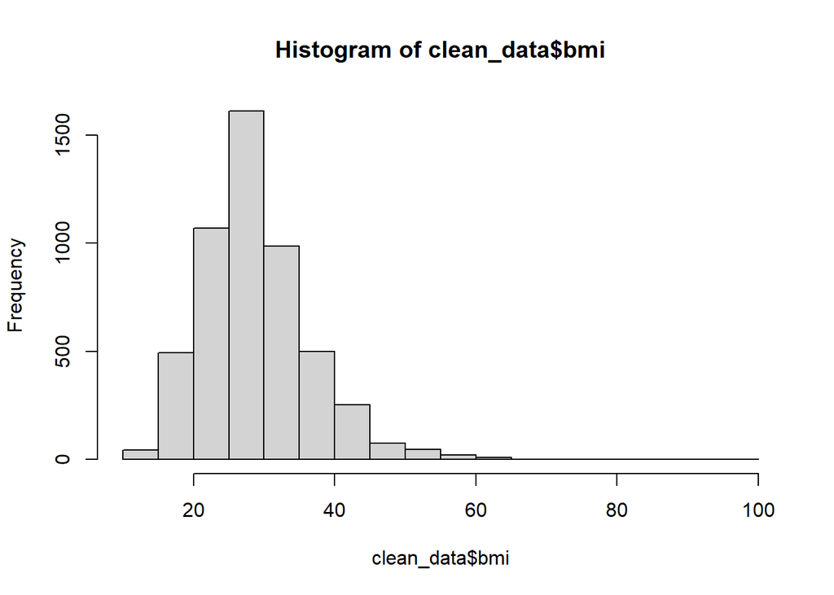

```r
# Assuming your dataframe is 'my_data' and the column is 'bmi'
clean_data <- clean_data %>%
  mutate(
    # na_if() turns the text "N/A" into a real R missing value (NA)
    # as.numeric() forces the column back to numbers so we can do math on it
    bmi = as.numeric(na_if(bmi, "N/A"))
  )


#replace this with mean as the demographic value like bmi have normal distribution
clean_data <- clean_data %>%
  mutate(
    bmi = replace_na(bmi,mean(bmi,na.rm=TRUE))
  )

hist(clean_data$bmi)
```

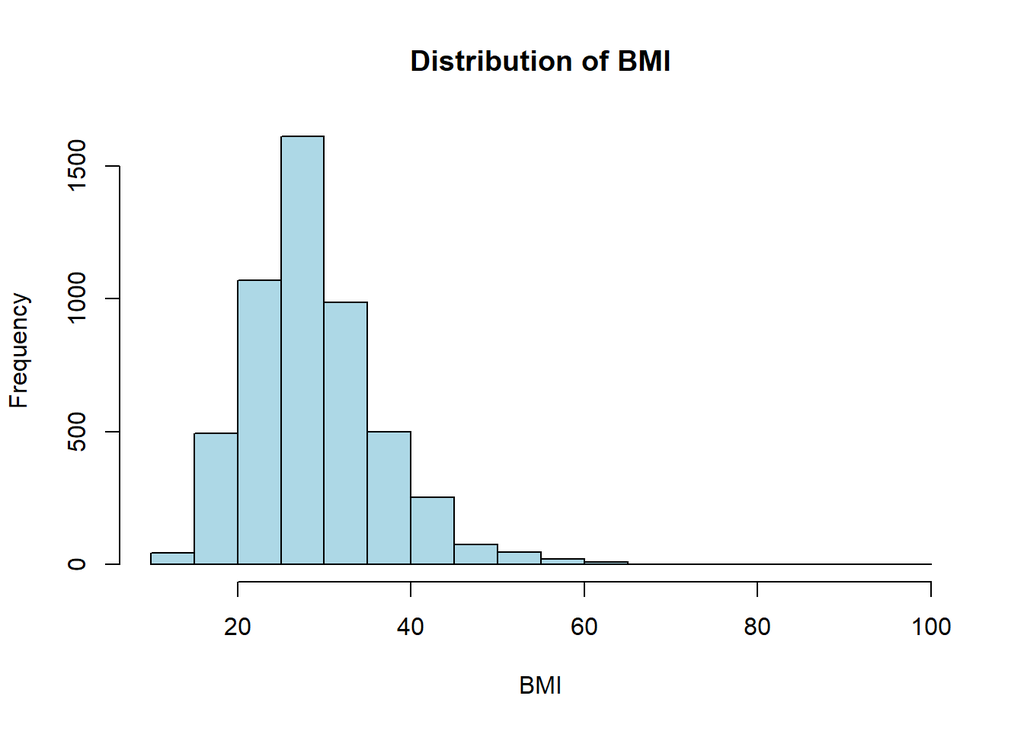

```r
hist(clean_data$bmi,
     main = "Distribution of BMI",  # Adds a title
     xlab = "BMI",                  # Labels the X-axis
     col = "lightblue")
```

```r
#it is found that the gender , residence , smoking type , work type and marriage consist of string .
#for data profiling it is important to convert them into integer incoding.
clean_data %>%
  count(gender,sort=TRUE) #shows unique string and frequency
```

```
## # A tibble: 3 × 2
##   gender     n
##   <chr>  <int>
## 1 Female  2994
## 2 Male    2115
## 3 Other      1
```

```r
clean_data %>%
  count(residence_type,sort=TRUE)
```

```
## # A tibble: 2 × 2
##   residence_type     n
##   <chr>          <int>
## 1 Urban           2596
## 2 Rural           2514
```

```r
clean_data %>%
  count(work_type,sort=TRUE)
```

```
## # A tibble: 5 × 2
##   work_type         n
##   <chr>         <int>
## 1 Private        2925
## 2 Self-employed   819
## 3 children        687
## 4 Govt_job        657
## 5 Never_worked     22
```

```r
clean_data %>%
  count(ever_married,sort=TRUE)
```

```
## # A tibble: 2 × 2
##   ever_married     n
##   <chr>        <int>
## 1 Yes           3353
## 2 No            1757
```

```r
clean_data %>%
  count(smoking_status,sort=TRUE)
```

```
## # A tibble: 4 × 2
##   smoking_status      n
##   <chr>           <int>
## 1 never smoked     1892
## 2 Unknown          1544
## 3 formerly smoked   885
## 4 smokes            789
```

```r
#change the row whose gender is other as Male

clean_data<-clean_data %>%
  mutate(gender=case_when(gender=="Other"~"Male",TRUE~gender))

#According to research quiting smoking help reduce the stroke risk by 34% . it should be numbered less than unknown
#encoding string column as research shows quiting is better than not availability about it .

my_data=clean_data


my_data <- my_data %>%
  dummy_cols(select_columns = "work_type",
             remove_first_dummy = FALSE) # This drops the first alphabetical category

my_data <- my_data %>%
  dummy_cols(select_columns = "residence_type",
             remove_first_dummy = FALSE)

my_data <- my_data %>%
  dummy_cols(select_columns = "smoking_status",
             remove_first_dummy = FALSE)
my_data <- my_data %>%


  mutate(marriage_encoded = if_else(ever_married == "Yes", 1, 0))

my_data <- my_data %>%


  mutate(marriage_encoded = if_else(ever_married == "Yes", 1, 0))



# Check if gender matters when you also factor in smoking
my_data %>%
  group_by(gender, smoking_status) %>%
  summarise(
    total_people = n(),
    stroke_rate = (sum(stroke == 1, na.rm = TRUE) / n()) * 100
  )
```

```
## `summarise()` has regrouped the output.
## ℹ Summaries were computed grouped by gender and smoking_status.
## ℹ Output is grouped by gender.
## ℹ Use `summarise(.groups = "drop_last")` to silence this message.
## ℹ Use `summarise(.by = c(gender, smoking_status))` for per-operation grouping
##   (`?dplyr::dplyr_by`) instead.
```

```
## # A tibble: 8 × 4
## # Groups:   gender [2]
##   gender smoking_status  total_people stroke_rate
##   <chr>  <chr>                  <int>       <dbl>
## 1 Female Unknown                  836        2.99
## 2 Female formerly smoked          477        7.13
## 3 Female never smoked            1229        5.13
## 4 Female smokes                   452        4.20
## 5 Male   Unknown                  708        3.11
## 6 Male   formerly smoked          408        8.82
## 7 Male   never smoked             663        4.07
## 8 Male   smokes                   337        6.82
```

```r
#one hot encoding as both gender have specific category that have fluctuation in data
my_data <- my_data %>%
  dummy_cols(select_columns = "gender",
             remove_first_dummy = TRUE)

summary(my_data)
```

```
##        id              gender          age         hypertension
##  Min.   :   67   Length   :5110   Min.   : 0.08   Min.   :0.00000
##  1st Qu.:17741   N.unique :   2   1st Qu.:25.00   1st Qu.:0.00000
##  Median :36932   N.blank  :   0   Median :45.00   Median :0.00000
##  Mean   :36518   Min.nchar:   4   Mean   :43.23   Mean   :0.09746
##  3rd Qu.:54682   Max.nchar:   6   3rd Qu.:61.00   3rd Qu.:0.00000
##  Max.   :72940                    Max.   :82.00   Max.   :1.00000
##  heart_disease        ever_married      work_type      residence_type
##  Min.   :0.00000   Length   :5110   Length   :5110   Length   :5110
##  1st Qu.:0.00000   N.unique :   2   N.unique :   5   N.unique :   2
##  Median :0.00000   N.blank  :   0   N.blank  :   0   N.blank  :   0
##  Mean   :0.05401   Min.nchar:   2   Min.nchar:   7   Min.nchar:   5
##  3rd Qu.:0.00000   Max.nchar:   3   Max.nchar:  13   Max.nchar:   5
##  Max.   :1.00000
##  avg_glucose_level      bmi          smoking_status     stroke
##  Min.   : 55.12    Min.   :10.30   Length   :5110   Min.   :0.00000
##  1st Qu.: 77.25    1st Qu.:23.80   N.unique :   4   1st Qu.:0.00000
##  Median : 91.89    Median :28.40   N.blank  :   0   Median :0.00000
##  Mean   :106.15    Mean   :28.89   Min.nchar:   6   Mean   :0.04873
##  3rd Qu.:114.09    3rd Qu.:32.80   Max.nchar:  15   3rd Qu.:0.00000
##  Max.   :271.74    Max.   :97.60                    Max.   :1.00000
##  work_type_children work_type_Govt_job work_type_Never_worked work_type_Private
##  Min.   :0.0000     Min.   :0.0000     Min.   :0.000000       Min.   :0.0000
##  1st Qu.:0.0000     1st Qu.:0.0000     1st Qu.:0.000000       1st Qu.:0.0000
##  Median :0.0000     Median :0.0000     Median :0.000000       Median :1.0000
##  Mean   :0.1344     Mean   :0.1286     Mean   :0.004305       Mean   :0.5724
##  3rd Qu.:0.0000     3rd Qu.:0.0000     3rd Qu.:0.000000       3rd Qu.:1.0000
##  Max.   :1.0000     Max.   :1.0000     Max.   :1.000000       Max.   :1.0000
##  work_type_Self-employed residence_type_Rural residence_type_Urban
##  Min.   :0.0000          Min.   :0.000        Min.   :0.000
##  1st Qu.:0.0000          1st Qu.:0.000        1st Qu.:0.000
##  Median :0.0000          Median :0.000        Median :1.000
##  Mean   :0.1603          Mean   :0.492        Mean   :0.508
##  3rd Qu.:0.0000          3rd Qu.:1.000        3rd Qu.:1.000
##  Max.   :1.0000          Max.   :1.000        Max.   :1.000
##  smoking_status_formerly smoked smoking_status_never smoked
##  Min.   :0.0000                 Min.   :0.0000
##  1st Qu.:0.0000                 1st Qu.:0.0000
##  Median :0.0000                 Median :0.0000
##  Mean   :0.1732                 Mean   :0.3703
##  3rd Qu.:0.0000                 3rd Qu.:1.0000
##  Max.   :1.0000                 Max.   :1.0000
##  smoking_status_smokes smoking_status_Unknown marriage_encoded  gender_Male
##  Min.   :0.0000        Min.   :0.0000         Min.   :0.0000   Min.   :0.0000
##  1st Qu.:0.0000        1st Qu.:0.0000         1st Qu.:0.0000   1st Qu.:0.0000
##  Median :0.0000        Median :0.0000         Median :1.0000   Median :0.0000
##  Mean   :0.1544        Mean   :0.3022         Mean   :0.6562   Mean   :0.4141
##  3rd Qu.:0.0000        3rd Qu.:1.0000         3rd Qu.:1.0000   3rd Qu.:1.0000
##  Max.   :1.0000        Max.   :1.0000         Max.   :1.0000   Max.   :1.0000
```

```r
# 1. Convert the stroke column to a factor with meaningful labels
my_data <- my_data %>%
  mutate(stroke = factor(stroke,
                         levels = c(0, 1),
                         labels = c("No", "Yes")))
```

# Task Two: Build prediction models

```r
#after addressing the data profiling by converting null and encoding the string
#Now we will procced to build the prediction models . By first spliting the data into 80-20 for train and split
library(tidymodels)
set.seed(123)

# strokes vs non-strokes in both sets.
data_split <- initial_split(my_data, prop = 0.8, strata = stroke)

train_data <- training(data_split)
test_data  <- testing(data_split)

# 1. Build the recipe using the training data
stroke_recipe <- recipe(stroke ~ ., data = train_data) %>%

  # Step 1: Explicitly remove the original raw text/string columns
  step_rm(id,gender, work_type, ever_married, smoking_status,residence_type) %>%

  # Step 2: Handle any missing numeric values
  step_impute_mean(all_numeric_predictors()) %>%

  # Step 3: Normalize all numeric and encoded columns so they are on the same scale
  step_normalize(all_numeric_predictors())



#To improve the accuracy of model. i will apply three model and keep the best model

#Linear regression model
log_reg_model <- logistic_reg() %>%
  set_engine("glm") %>%
  set_mode("classification")

# 2. Create the workflow object
stroke_workflow <- workflow() %>%
  add_recipe(stroke_recipe) %>%  #  recipe with step_normalize()
  add_model(log_reg_model)       # The model just defined

stroke_fit <- stroke_workflow %>%
  fit(data = train_data)

#shows the coefficient for the regression model
stroke_fit
```

```
## ══ Workflow [trained] ══════════════════════════════════════════════════════════
## Preprocessor: Recipe
## Model: logistic_reg()
##
## ── Preprocessor ────────────────────────────────────────────────────────────────
## 3 Recipe Steps
##
## • step_rm()
## • step_impute_mean()
## • step_normalize()
##
## ── Model ───────────────────────────────────────────────────────────────────────
##
## Call:  stats::glm(formula = ..y ~ ., family = stats::binomial, data = data)
##
## Coefficients:
##                      (Intercept)                               age
##                         -4.04779                           1.70116
##                     hypertension                     heart_disease
##                          0.14473                           0.06027
##                avg_glucose_level                               bmi
##                          0.21890                          -0.01693
##               work_type_children                work_type_Govt_job
##                          0.54167                           0.08126
##           work_type_Never_worked                 work_type_Private
##                         -0.61262                           0.21085
##        `work_type_Self-employed`              residence_type_Rural
##                               NA                          -0.06719
##             residence_type_Urban  `smoking_status_formerly smoked`
##                               NA                           0.03325
##    `smoking_status_never smoked`             smoking_status_smokes
##                         -0.05499                           0.08434
##           smoking_status_Unknown                  marriage_encoded
##                               NA                          -0.06062
##                      gender_Male
##                         -0.02183
##
## Degrees of Freedom: 4087 Total (i.e. Null);  4072 Residual
## Null Deviance:       1549
## Residual Deviance: 1228  AIC: 1260
```

```r
#random forest model
rf_model <- rand_forest(trees = 500) %>%
  set_engine("ranger", importance = "impurity") %>%
  set_mode("classification")

# 2. Create the workflow
rf_workflow <- workflow() %>%
  add_recipe(stroke_recipe) %>% # Reusing your existing recipe!
  add_model(rf_model)

# 3. Train the model
rf_fit <- rf_workflow %>%
  fit(data = train_data)

# Print a quick summary
rf_fit
```

```
## ══ Workflow [trained] ══════════════════════════════════════════════════════════
## Preprocessor: Recipe
## Model: rand_forest()
##
## ── Preprocessor ────────────────────────────────────────────────────────────────
## 3 Recipe Steps
##
## • step_rm()
## • step_impute_mean()
## • step_normalize()
##
## ── Model ───────────────────────────────────────────────────────────────────────
## Ranger result
##
## Call:
##  ranger::ranger(x = maybe_data_frame(x), y = y, num.trees = ~500,      importance = ~"impurity", num.threads = 1, verbose = FALSE,      seed = sample.int(10^5, 1), probability = TRUE)
##
## Type:                             Probability estimation
## Number of trees:                  500
## Sample size:                      4088
## Number of independent variables:  18
## Mtry:                             4
## Target node size:                 10
## Variable importance mode:         impurity
## Splitrule:                        gini
## OOB prediction error (Brier s.):  0.04196956
```

```r
# Neural Network Model
# hidden_units = number of nodes in the hidden layer
# penalty = regularization to prevent overfitting
nn_model <- mlp(hidden_units = 5, penalty = 0.01) %>%
  set_engine("nnet") %>%
  set_mode("classification")

# 2. Create the workflow
nn_workflow <- workflow() %>%
  add_recipe(stroke_recipe) %>%
  add_model(nn_model)

# 3. Train the model
# (This might take a few seconds depending on your machine)
nn_fit <- nn_workflow %>%
  fit(data = train_data)

# Print a quick summary
nn_fit
```

```
## ══ Workflow [trained] ══════════════════════════════════════════════════════════
## Preprocessor: Recipe
## Model: mlp()
##
## ── Preprocessor ────────────────────────────────────────────────────────────────
## 3 Recipe Steps
##
## • step_rm()
## • step_impute_mean()
## • step_normalize()
##
## ── Model ───────────────────────────────────────────────────────────────────────
## a 18-5-1 network with 101 weights
## inputs: age hypertension heart_disease avg_glucose_level bmi work_type_children work_type_Govt_job work_type_Never_worked work_type_Private `work_type_Self-employed` residence_type_Rural residence_type_Urban `smoking_status_formerly smoked` `smoking_status_never smoked` smoking_status_smokes smok…
## output(s): ..y
## options were - entropy fitting  decay=0.01
```

```r
#Now is the best time to test the model predictibility and determine there accuracy and adapt to the best model

#let us start with logistical regression model
#renaming help to remember the predicted model
log_reg_preds <- predict(stroke_fit, new_data = test_data) %>%
  rename(pred_log_reg = .pred_class)

# 2. Predict using Random Forest
rf_preds <- predict(rf_fit, new_data = test_data) %>%
  rename(pred_rf = .pred_class)

# 3. Predict using Neural Network
nn_preds <- predict(nn_fit, new_data = test_data) %>%
  rename(pred_nn = .pred_class)
```

# Task Three: Evaluate and select prediction models

```r
#with all these model come the challenge to choose the one
#statistics offer the model to choose one
#i am going to check the data on the basis of different #metrics including accuracy, recall, precision specificity

# Create the results dataframe
results_df <- test_data %>%
  select(actual_stroke = stroke) %>%
  bind_cols(log_reg_preds, rf_preds, nn_preds)

# Now check that this object exists:
head(results_df)
```

```
## # A tibble: 6 × 4
##   actual_stroke pred_log_reg pred_rf pred_nn
##   <fct>         <fct>        <fct>   <fct>
## 1 Yes           No           No      No
## 2 Yes           No           No      No
## 3 Yes           No           No      No
## 4 Yes           No           No      No
## 5 Yes           No           No      No
## 6 Yes           No           No      No
```

```r
checking_metrics <- metric_set(accuracy, sens, spec, precision)

#let me start with logistic regression
checking_metrics(results_df, truth = actual_stroke, estimate = pred_log_reg)
```

```
## # A tibble: 4 × 3
##   .metric   .estimator .estimate
##   <chr>     <chr>          <dbl>
## 1 accuracy  binary        0.945
## 2 sens      binary        1
## 3 spec      binary        0.0175
## 4 precision binary        0.945
```

```r
#Random forest
checking_metrics(results_df, truth = actual_stroke, estimate = pred_rf)
```

```
## # A tibble: 4 × 3
##   .metric   .estimator .estimate
##   <chr>     <chr>          <dbl>
## 1 accuracy  binary         0.944
## 2 sens      binary         1
## 3 spec      binary         0
## 4 precision binary         0.944
```

```r
#neural network
checking_metrics(results_df, truth = actual_stroke, estimate = pred_nn)
```

```
## # A tibble: 4 × 3
##   .metric   .estimator .estimate
##   <chr>     <chr>          <dbl>
## 1 accuracy  binary         0.944
## 2 sens      binary         1
## 3 spec      binary         0
## 4 precision binary         0.944
```